# Pregunta 04

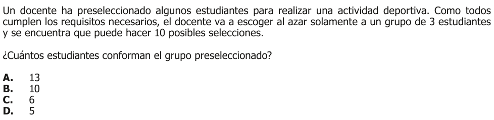

### Análisis

El problema nos dice que un docente ha preseleccionado un grupo de estudiantes, pero necesita seleccionar al azar un grupo de **3 estudiantes**. Además, nos informan que hay **10 posibles selecciones** para formar este grupo de 3 estudiantes.

### Identificación del concepto clave

El número de formas en que se puede elegir un subconjunto de elementos de un conjunto mayor sin importar el orden, se calcula utilizando las **combinaciones**. La fórmula general para las combinaciones es:

$$C(n, r) = \frac{n!}{r!(n-r)!}$$

Donde:

- $n$: Número total de elementos en el conjunto.
- $r$: Número de elementos seleccionados.
- $n!$: Factorial de $n$, que se calcula como $n \times (n-1) \times (n-2) \times \ldots \times 1$.

### Aplicación al problema

Aquí sabemos que:

- $r = 3$ (se seleccionan 3 estudiantes).
- $C(n, 3) = 10$ (hay 10 formas posibles de hacer esta selección).

Necesitamos encontrar el valor de $n$, que es el número total de estudiantes en el grupo preseleccionado. Utilizamos la fórmula de combinaciones:

$$C(n, 3) = \frac{n!}{3!(n-3)!} = 10$$

Sabemos que $3! = 3 \times 2 \times 1 = 6$, así que la ecuación se simplifica a:

$$\frac{n(n-1)(n-2)}{6} = 10$$

Multiplicamos ambos lados de la ecuación por 6 para eliminar el denominador:

$$n(n-1)(n-2) = 60$$

### Resolución de la ecuación

Expandiendo los términos:

1. Probamos valores para $n$ hasta que la ecuación sea válida.
   - Para $n = 5$:
     $$5 \cdot 4 \cdot 3 = 60$$

Esto satisface la ecuación, por lo que el número total de estudiantes preseleccionados es **5**.

### Respuesta correcta

La respuesta es:

**D. 5**

### Análisis de la Pregunta 2023-Matematicas-11-1-04, según SABER 11 ICFES

- Nivel de Desempeño: 4
- Competencia: Formulación y Ejecución
  - Aprendizaje: Frente a un problema que involucre información cuantitativa, plantea e implementa estrategias que lleven a soluciones adecuadas.
  - Evidencia: Ejecuta un plan de solución para un problema que involucra información cuantitativa o esquemática.
- Componente: Aleatorio
- Estándar Asociado: Resuelvo y planteo problemas usando conceptos básicos de conteo y probabilidad (combinaciones, permutaciones, espacio muestral, muestreo aleatorio, muestreo con reemplazo).
- ¿Qué evalúa?: La capacidad de determinar el tamaño de un conjunto dado el número de combinaciones posibles al seleccionar un subconjunto específico.
- Respuesta Correcta: D. 5, porque al aplicar la fórmula de combinaciones $C(n,3) = \frac{n!}{3!(n-3)!} = 10$, se obtiene que n = 5 satisface la ecuación.
- Distractores:
  - A. 13: El estudiante podría llegar a este resultado al:
    - Sumar el número de combinaciones posibles (10) con el número de estudiantes a seleccionar (3)
    - Reflejar una comprensión superficial del problema donde simplemente opera con los números dados
    - No comprender el concepto de combinaciones ni su relación con el tamaño del conjunto original
  - B. 10: El estudiante podría seleccionar esta opción al:
    - Confundir el número de combinaciones posibles con el tamaño del conjunto original
    - No distinguir entre el resultado de la operación combinatoria y los elementos del conjunto inicial
    - Mostrar una interpretación literal del dato “10 posibles selecciones” como si fuera el número total de estudiantes
  - C. 6: El estudiante podría obtener este resultado al:
    - Confundir el denominador de la fórmula de combinaciones (3! = 6) con el tamaño del conjunto
    - Realizar una manipulación incorrecta de la fórmula $C(n,3) = \frac{n!}{3!(n-3)!}$
    - No verificar si su respuesta es coherente con el contexto del problema
    - Mostrar una comprensión parcial de la fórmula de combinaciones donde solo identifica algunos elementos sin entender su significado completo
- Contenidos Matemáticos Curriculares: Estadística
  - Período: 3
    - Conjuntos, Combinatoria y Probabilidad
      - Combinaciones
- No genérico
- Eje Axial Disciplinar: Eje 4 (Conjuntos, Casillas y Combinaciones)
- Tarea: Determinar el tamaño de un conjunto dado el número de combinaciones posibles al seleccionar un subconjunto de tamaño específico.
- Grado: 11°